# SAD_PEC2_25_1S_Solución

Equipo docente SAD

2025-10-01

## Software para el análisis de datos (SAD).

## Prueba de evaluación continua (PEC2). Propuesta de solución.

Para realizar la PEC2, es necesario haber trabajado los siguientes laboratorios y recursos asociados:

- LAB 3. Fundamentos de programación y acceso a base de datos en R
- LAB 4. Probabilidad y simulación en R

La PEC2 consta de diversos ejercicios organizados en secciones que corresponden a cada uno de los contenidos de los diferentes laboratorios.

### Sección 1. Fundamentos de programación y BBDD (5 puntos)

**Ejercicio 1.** (1 punto)

Interpretad el siguiente código que hace referencia a genes, su nivel de expresión (en TPM) y la categoría funcional a la que pertenecen (0.2 puntos). Mostrad cuál sería el resultado obtenido:

```r
genes <- matrix(c(
  "BRCA1", 120, "Reparación de ADN",
  "TP53", 300, "Supresor tumoral",
  "MYC", 500, "Oncogén",
  "GAPDH", 1000, "Control interno",
  "EGFR", 250, "Receptor de membrana"
), nrow = 5, byrow = TRUE)

print("Matriz de genes:")
```

```
## [1] "Matriz de genes:"
```

```r
print(genes)
```

```
##      [,1]    [,2]   [,3]
## [1,] "BRCA1" "120"  "Reparación de ADN"
## [2,] "TP53"  "300"  "Supresor tumoral"
## [3,] "MYC"   "500"  "Oncogén"
## [4,] "GAPDH" "1000" "Control interno"
## [5,] "EGFR"  "250"  "Receptor de membrana"
```

Cuestiones:

1. ¿Por qué es necesario usar *c()* para crear la matriz en R (0.2 puntos)?

```
La función matrix() necesita un vector como entrada, y c() concatena todos los elementos en un único vector que luego se organiza en filas y columnas.
```

2. ¿Qué estructura de datos en R resultaría más adecuada para representar información de genes con distintos tipos de datos (texto, número y categoría) (0.2 puntos)?

```
Un data frame (data.frame) sería más apropiado, ya que permite combinar distintos tipos de datos: caracteres (genes), numéricos (TPM) y factores (categoría funcional).
```

3. ¿Cómo cambiaría la visualización de la matriz si se eliminan los argumentos *nrow=5*, *byrow=TRUE* de la función *matrix()* (0.2 puntos)?

```
Sin nrow=5, R no sabrá que queremos 5 filas -> generará una matriz con una forma distinta (tantas filas como pueda ajustar por defecto).
Sin byrow=TRUE, R rellenará la matriz por columnas en lugar de por filas. Los genes no quedarían en la misma fila que sus datos asociados, se mezclaría la información.
```

Escribid un código que recorra las filas de la matriz y muestre por pantalla la lista de genes que sean oncogenes o supresores tumorales, junto con su nivel de expresión (0.2 puntos).

El resultado esperado debe tener el siguiente formato:

```
Lista de genes relevantes en cáncer:
Gen: TP53 - Expresión: 300 TPM
Gen: MYC - Expresión: 500 TPM
```

Nota: Para resolver esta tarea, utilizad bucles (*for*) e instrucciones condicionales (*if*), no funciones predeterminadas de filtrado en R.

```
# Recorremos la matriz y aplicamos condiciones
print("Lista de genes relevantes en cáncer:")

for (i in 1:nrow(genes)) {
  categoria <- genes[i, 3]

  if (categoria == "Oncogén" | categoria == "Supresor tumoral") {
    gen <- genes[i, 1]
    expresion <- genes[i, 2]

    cat("Gen:", gen, "- Expresión:", expresion, "TPM\n")
  }
}
```

**Ejercicio 2.** (2 puntos)

Supongamos que queremos calcular el índice de expresión relativa de un gen en un experimento de qPCR, comparando el nivel de expresión de un gen de interés con el de un gen de referencia.

Se pide:

1. (0.5 puntos) Definir una función en R llamada *indice_expresion* que reciba dos parámetros:
- *exp_interes*: nivel de expresión del gen de interés.
- *exp_referencia*: nivel de expresión del gen de referencia.

La función debe calcular y devolver el índice de expresión relativa, definido como:

$Indice = \frac{exp\_interes}{exp\_referencia}$

2. (0.5 puntos) Mostrar el resultado por pantalla suponiendo, por ejemplo:
- *exp_interes = 250*
- *exp_referencia = 100*
3. (0.5 puntos) Probar la función con diferentes ejemplos para comprobar la consistencia del código:
- Valores numéricos distintos.
- Casos de error, por ejemplo cuando el valor de referencia sea 0 (evitar división entre cero).
- Casos en los que los parámetros no sean numéricos.
4. (0.5 puntos) Analizar cómo se pueden definir los parámetros:
- Introduciéndolos directamente en el código.
- Pidiéndolos al usuario mediante la función readline().

```r
indice_expresion <- function(exp_interes, exp_referencia) {
  # Comprobar que ambos parámetros son numéricos
  if (!is.numeric(exp_interes) | !is.numeric(exp_referencia)) {
    stop("Error: los valores deben ser numéricos.")
  }

  # Comprobar que el valor de referencia no sea cero
  if (exp_referencia == 0) {
    stop("Error: la expresión de referencia no puede ser cero (división por cero).")
  }

  # Calcular índice
  indice <- exp_interes / exp_referencia

  # Mostrar resultado en pantalla
  cat("Índice de expresión relativa:", indice, "\n")

  return(indice)
}
```

```r
# Ejemplo 1
indice_expresion(250, 100)
```

```
## Índice de expresión relativa: 2.5
```

```
## [1] 2.5
```

```r
# Ejemplo 2: expresión menor que la referencia
indice_expresion(50, 200)   # esperado: 0.25
```

```
## Índice de expresión relativa: 0.25
```

```
## [1] 0.25
```

```r
# Ejemplo 3: valores grandes
indice_expresion(10000, 4000)  # esperado: 2.5
```

```
## Índice de expresión relativa: 2.5
```

```
## [1] 2.5
```

```r
# Ejemplo 4: error - referencia igual a 0
#indice_expresion(300, 0)

# Ejemplo 5: error - entrada no numérica
#indice_expresion("ABC", 100)
```

```r
# Pedir al usuario que introduzca valores
exp_interes <- as.numeric(readline(prompt = "Introduce expresión del gen de interés: "))
```

```
## Introduce expresión del gen de interés:
```

```r
exp_referencia <- as.numeric(readline(prompt = "Introduce expresión del gen de referencia: "))
```

```
## Introduce expresión del gen de referencia:
```

```r
# Llamar a la función con los valores dados por el usuario
# indice_expresion(exp_interes, exp_referencia)
```

**Ejercicio 3.** (2 puntos)

A partir del dataset ToothGrowth del paquete datasets, utilizad RSQLite y las instrucciones asociadas para explorar dicho conjunto de datos. Podéis encontrar más información de la descripción de este dataset en: https://www.rdocumentation.org/packages/datasets/topics/ToothGrowth.

Este dataset contiene:

- *len*: longitud del diente (respuesta).
- *supp*: tipo de suplemento (*VC* = ácido ascórbico, *OJ* = jugo de naranja).
- *dose*: dosis de vitamina C administrada (en mg/día).

```r
# Paquetes
library(DBI)
library(RSQLite)

# Conexión a base de datos en memoria
con <- dbConnect(RSQLite::SQLite(), ":memory:")

# Cargar dataset ToothGrowth en R
data("ToothGrowth")

# Pasar datos a la base de datos
dbWriteTable(con, "ToothGrowth", ToothGrowth)
```

1. Mostrad la longitud media del diente (*len*) en las cobayas que recibieron una dosis de al menos 1 mg/día (0.5 puntos).

```r
query_a <- "
SELECT AVG(len) AS media_len
FROM ToothGrowth
WHERE dose >= 1
"

dbGetQuery(con, query_a)
```

```
##   media_len
## 1   22.9175
```

2. Mostrad la longitud y la dosis de aquellas cobayas tratadas con jugo de naranja (*supp = “OJ”*) cuya longitud del diente sea superior a 20 (0.5 puntos).

```r
query_b <- "
SELECT len, dose
FROM ToothGrowth
WHERE supp = 'OJ' AND len > 20
"

dbGetQuery(con, query_b)
```

```
##     len dose
## 1  21.5  0.5
## 2  23.3  1.0
## 3  23.6  1.0
## 4  26.4  1.0
## 5  25.2  1.0
## 6  25.8  1.0
## 7  21.2  1.0
## 8  27.3  1.0
## 9  25.5  2.0
## 10 26.4  2.0
## 11 22.4  2.0
## 12 24.5  2.0
## 13 24.8  2.0
## 14 30.9  2.0
## 15 26.4  2.0
## 16 27.3  2.0
## 17 29.4  2.0
## 18 23.0  2.0
```

3. Mostrad cuántos animales fueron tratados con cada tipo de suplemento (*supp*), agrupando los resultados por suplemento y ordenándolos de mayor a menor número de animales (0.5 puntos).

```r
query_c <- "
SELECT supp, COUNT(*) AS num_animales
FROM ToothGrowth
GROUP BY supp
ORDER BY num_animales DESC
"

dbGetQuery(con, query_c)
```

```
##   supp num_animales
## 1   VC           30
## 2   OJ           30
```

4. Mostrad la longitud media del diente agrupada por dosis y tipo de suplemento (*supp* y *dose*) (0.5 puntos).

```r
query_d <- "
SELECT supp, dose, AVG(len) AS media_len
FROM ToothGrowth
GROUP BY supp, dose
ORDER BY supp, dose
"

dbGetQuery(con, query_d)
```

```
##   supp dose media_len
## 1   OJ  0.5     13.23
## 2   OJ  1.0     22.70
## 3   OJ  2.0     26.06
## 4   VC  0.5      7.98
## 5   VC  1.0     16.77
## 6   VC  2.0     26.14
```

```r
dbDisconnect(con)
```

### Sección 2. Probabilidad y simulación (5 puntos)

**Ejercicio 4.** (2.5 puntos)

En este ejercicio estudiaremos el crecimiento de bacterias en un medio de cultivo usando distribuciones estadísticas y simulaciones en R. El número de horas que tarda una colonia de bacterias en duplicar su tamaño sigue aproximadamente una distribución log-normal con parámetros de media logarítmica (*meanlog*) igual a 1.2 y desviación típica logarítmica (*sdlog*) igual a 0.3. Si se añade un antibiótico, este tiempo de duplicación se ajusta bien a una distribución log-normal con *meanlog = 1.5* y *sdlog = 0.4*.

1. Graficad las densidades de los tiempos de duplicación en ambos escenarios (con y sin antibiótico). Comentad qué diferencias observáis en los gráficos (0.6 puntos).

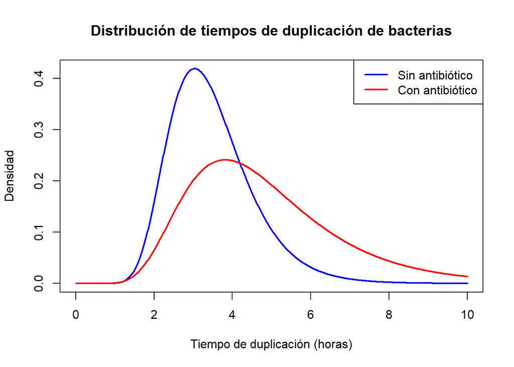

```
Comentario: La curva con antibiótico está desplazada hacia la derecha; los tiempos de duplicación son mayores. Además, la distribución con antibiótico es más dispersa (cola más larga), reflejando mayor variabilidad.
```

```r
# Parámetros
meanlog_normal <- 1.2; sdlog_normal <- 0.3
meanlog_antib <- 1.5; sdlog_antib <- 0.4

# Rango de tiempos de duplicación
x <- seq(0, 10, length.out = 1000)

# Densidades
dens_normal <- dlnorm(x, meanlog = meanlog_normal, sdlog = sdlog_normal)
dens_antib <- dlnorm(x, meanlog = meanlog_antib, sdlog = sdlog_antib)

# Gráfico
plot(x, dens_normal, type = "l", col = "blue", lwd = 2,
     ylab = "Densidad", xlab = "Tiempo de duplicación (horas)",
     main = "Distribución de tiempos de duplicación de bacterias")
lines(x, dens_antib, col = "red", lwd = 2)
legend("topright", legend = c("Sin antibiótico", "Con antibiótico"),
       col = c("blue", "red"), lwd = 2)
```

2. Calculad la probabilidad de que el tiempo de duplicación sea inferior a 2 horas en ambos casos. Después, calculad la probabilidad de que el tiempo sea superior a 5 horas. Realizad los cálculos exactos y comentad los resultados (0.6 puntos).

```r
# Probabilidad de duplicación < 2 horas
p_normal_2 <- plnorm(2, meanlog_normal, sdlog_normal)
p_antib_2  <- plnorm(2, meanlog_antib, sdlog_antib)

# Probabilidad de duplicación > 5 horas
p_normal_5 <- 1 - plnorm(5, meanlog_normal, sdlog_normal)
p_antib_5  <- 1 - plnorm(5, meanlog_antib, sdlog_antib)

p_normal_2; p_antib_2
```

```
## [1] 0.04556093
```

```
## [1] 0.02184087
```

```r
p_normal_5; p_antib_5
```

```
## [1] 0.08615905
```

```
## [1] 0.392198
```

```
Comentario: Sin antibiótico hay mayor probabilidad de duplicar antes de 2h. Con antibiótico aumenta la probabilidad de tardar más de 5h en duplicar.
```

3. A través de 10000 simulaciones para cada escenario, estimad la media, varianza y percentiles 25%, 50% y 75% del tiempo de duplicación. Comparad estos valores con los obtenidos de forma exacta con la función qlnorm de R (0.8 puntos).

```r
set.seed(123)

# Simulaciones
sim_normal <- rlnorm(10000, meanlog_normal, sdlog_normal)
sim_antib  <- rlnorm(10000, meanlog_antib, sdlog_antib)

# Estadísticos simulados
stats_normal <- c(mean(sim_normal), var(sim_normal), quantile(sim_normal, c(0.25,0.5,0.75)))
stats_antib  <- c(mean(sim_antib), var(sim_antib), quantile(sim_antib, c(0.25,0.5,0.75)))

# Valores exactos con qlnorm
exact_normal <- c(qlnorm(0.25, meanlog_normal, sdlog_normal),
                  qlnorm(0.5, meanlog_normal, sdlog_normal),
                  qlnorm(0.75, meanlog_normal, sdlog_normal))

exact_antib <- c(qlnorm(0.25, meanlog_antib, sdlog_antib),
                 qlnorm(0.5, meanlog_antib, sdlog_antib),
                 qlnorm(0.75, meanlog_antib, sdlog_antib))

stats_normal
```

```
##                        25%      50%      75%
## 3.470170 1.135041 2.717220 3.309090 4.063336
```

```r
stats_antib
```

```
##                        25%      50%      75%
## 4.839540 4.104550 3.415928 4.449748 5.862599
```

```r
exact_normal
```

```
## [1] 2.711910 3.320117 4.064728
```

```r
exact_antib
```

```
## [1] 3.421928 4.481689 5.869655
```

```
Comentario: La media y varianza simuladas se aproximan bien a los valores teóricos. Los percentiles 25%, 50% y 75% obtenidos mediante simulación son muy cercanos a los obtenidos con 'qlnorm'. Pequeñas discrepancias se deben al azar de la simulación.
```

4. Escribid una breve reflexión sobre los dilemas éticos relacionados con el uso de antibióticos en exceso y la resistencia bacteriana (0.5 puntos)

```
El uso de antibióticos modifica el crecimiento bacteriano, pero su uso indiscriminado puede favorecer la aparición de resistencias bacterianas. Estas resistencias suponen una amenaza para la salud global, pues reducen la eficacia de los tratamientos. Es fundamental usarlos de forma responsable, acompañados de medidas de prevención (higiene, vacunas, control epidemiológico), para evitar que pierdan su efectividad en el futuro.
```

**Ejercicio 5.** (2.5 puntos)

Queremos analizar el rendimiento de una vacuna contra una nueva enfermedad infecciosa. Supongamos que el 3% de la población no desarrolla inmunidad tras recibir la vacuna. Si una persona no desarrolla inmunidad, la probabilidad de infectarse al exponerse al virus es del 40%. Si una persona sí desarrolla inmunidad, la probabilidad de infectarse es solo del 2%.

1. Si seleccionamos 200 personas vacunadas, ¿cuál es la probabilidad de que al menos 5 se infecten? Calculadlo mediante un cálculo exacto (usando la binomial) y mediante 10000 simulaciones. Comparad los resultados (0.6 puntos).

```r
p_no_imm  <- 0.03
p_inf_no  <- 0.40
p_inf_yes <- 0.02

set.seed(42)
n_sims <- 10000
```

```
Cada persona vacunada tiene probabilidad marginal de infectarse
p = 0.03*0.40+0.97∗0.02 = 0.0314
```

```r
n <- 200
p_marginal <- p_no_imm * p_inf_no + (1 - p_no_imm) * p_inf_yes  # 0.0314

# Probabilidad de al menos 5 infectados
# Cálculo exacto
prob_at_least_5_exact <- 1 - pbinom(4, size = n, prob = p_marginal)
prob_at_least_5_exact
```

```
## [1] 0.7550876
```

```r
# Simulación
sim_at_least_5 <- replicate(n_sims, {
  # generar para 200 personas: si no desarrollan inmunidad (TRUE/FALSE)
  no_imm <- runif(n) < p_no_imm
  # para cada persona, prob de infectarse según su estado
  probs <- ifelse(no_imm, p_inf_no, p_inf_yes)
  infections <- rbinom(n, size = 1, prob = probs)
  sum(infections) >= 5
})
prob_at_least_5_sim <- mean(sim_at_least_5)
prob_at_least_5_sim
```

```
## [1] 0.7597
```

```
Comentario: Los dos resultados (exacto por Binomial(200,0.0314) y la simulación que modela la mezcla) son muy cercanos.
```

2. Si seleccionamos 50 personas que no desarrollan inmunidad, ¿cuál es la probabilidad de que ninguna se infecte? Y si seleccionamos 150 personas que sí desarrollan inmunidad, ¿cuál es la probabilidad de que al menos 3 se infecten? Resolvedlo con cálculos exactos y simulaciones (0.6 puntos).

```r
# 50 personas sin inmunidad: probabilidad de que ninguna se infecte
n_no_imm <- 50
prob_none_infected_no_imm_exact <- dbinom(0, size = n_no_imm, prob = p_inf_no)
prob_none_infected_no_imm_exact
```

```
## [1] 8.082813e-12
```

```r
sim_none_no_imm <- replicate(n_sims, {
  sum(rbinom(n_no_imm, size = 1, prob = p_inf_no)) == 0
})
prob_none_infected_no_imm_sim <- mean(sim_none_no_imm)
prob_none_infected_no_imm_sim
```

```
## [1] 0
```

```r
# 150 personas con inmunidad: probabilidad de que al menos 3 se infecten
n_yes_imm <- 150
prob_at_least_3_yes_imm_exact <- 1 - pbinom(2, size = n_yes_imm, prob = p_inf_yes)
prob_at_least_3_yes_imm_exact
```

```
## [1] 0.5790743
```

```r
sim_at_least_3_yes_imm <- replicate(n_sims, {
  sum(rbinom(n_yes_imm, size = 1, prob = p_inf_yes)) >= 3
})
prob_at_least_3_yes_imm_sim <- mean(sim_at_least_3_yes_imm)
prob_at_least_3_yes_imm_sim
```

```
## [1] 0.5822
```

3. Graficad la distribución de probabilidad del número de infecciones esperadas en los grupos de personas con inmunidad y sin inmunidad. Comentad las diferencias entre ambas distribuciones (0.7 puntos).

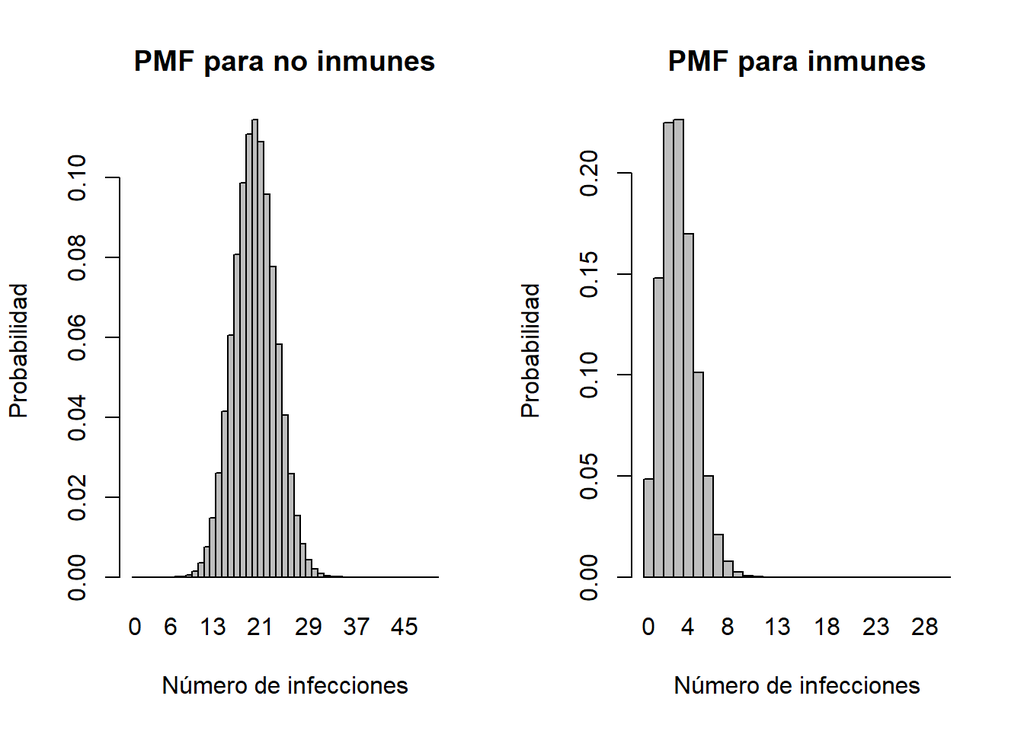

```r
# PMF para no inmunes (50, 0.4)
k1 <- 0:n_no_imm
pmf_no_imm <- dbinom(k1, size = n_no_imm, prob = p_inf_no)

# PMF para inmunes (150, 0.02)
k2 <- 0:30   # rango suficiente
pmf_yes_imm <- dbinom(k2, size = n_yes_imm, prob = p_inf_yes)

# Gráficos
par(mfrow = c(1,2))
barplot(pmf_no_imm, names.arg = k1, space = 0,
        main = "PMF para no inmunes", xlab = "Número de infecciones", ylab = "Probabilidad")
barplot(pmf_yes_imm, names.arg = k2, space = 0,
        main = "PMF para inmunes", xlab = "Número de infecciones", ylab = "Probabilidad")
```

```r
par(mfrow = c(1,1))
```

```
Comentario:
No inmunes (50, 0.4): media = 50*0.4 = 20. La distribución está centrada alrededor de ~20, con dispersión notable; la probabilidad de muchos infectados es grande.
Inmunes (150, 0.02): media = 150*0.02 = 3. La PMF está fuertemente concentrada en valores pequeños (0,1,2,3). La cola hacia la derecha existe, pero probabilidades para valores altos son muy pequeñas.
En conclusión, el grupo sin inmunidad tiene mucho mayor riesgo absoluto y una distribución desplazada a la derecha; el grupo inmune tiene pocas infecciones esperadas y alta probabilidad de 0–3 casos.
```

4. A partir de vuestros resultados y del hecho de que un pequeño porcentaje de vacunados no desarrolla inmunidad, redactad una breve justificación sobre si es más eficaz centrarse en reforzar la inmunidad individual o en reducir la exposición general al virus (0.6 puntos).

```
Comentario:
Sólo un 3% de vacunados no desarrolla inmunidad, y esos no inmunes tienen riesgo de infección mucho mayor (40% frente a 2%). Esto implica:

- En términos individuales, reforzar la inmunidad de ese 3% (por ejemplo, detectar no respondedores y administrar refuerzos/estrategias alternativas) reduce mucho el riesgo absoluto en ese subgrupo.

- En términos poblacionales, reducir la exposición (medidas de salud pública: mascarillas en brotes, ventilación, pruebas, rastreo, limitar eventos masivos) reduce el riesgo para todos, incluidos los no inmunes y los inmunes.

Dado que el porcentaje de no respondedores es pequeño pero su riesgo individual es alto, la política más eficaz es mixta:
1) Identificar y priorizar refuerzos/medidas para no respondedores (pruebas de respuesta inmunitaria, dosis de refuerzo, tratamientos profilácticos). Esto protege el subgrupo de alto riesgo de forma coste-efectiva.
2) Mantener medidas de reducción de exposición adaptativas (cuando la transmisión es alta) para bajar la probabilidad de contagio global y proteger tanto a no respondedores como a aquellos con respuesta parcial.
```